# 第10回 出だしの不運を直す

経済プログラミング特論II

第10回・開店 12 日目

出だしの不運を直す

ふだんは一番、たまにわざと

経済プログラミング特論II

第10回・開店 12 日目 — Topic01

行動価値の更新

記録を全部持たなくても、平均は直せる

## うちの店と 4 段の店長

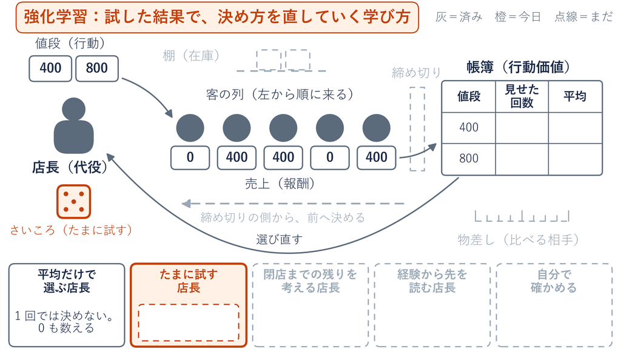

## 前の回の店長の 100 人の帳簿

前の回の、帳簿の数が高い値段を見せる店長を、  
計算機で 100 人ぶん動かした（seed 15 の客の並び）  
1 人目に見せた 400 円が売れず、そのあとは 800 円だけ

| 値段 | 見せた回数 | 平均 |
| --- | --- | --- |
| 400 円 | 1 | 0 円 |
| 800 円 | 99 | 234 円 |

100 人ぶんの売上：23200 円

400 円は、本当にだめな値段だったのか

## 前の店長と今日の店長の違い

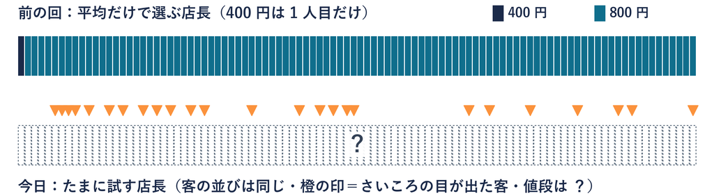

違うのは、店先のさいころ 1 つ

## 今日の道のり

1

平均を 1 回ずつ直す

実習：写経 update 関数

演習 1 800 円の 10 回

2

たまに別の値段を見せる

実習：写経 choose 関数

演習 2 eps を 0 に

3

試しの損得を数える

実習：写経 200 本を数える

演習 3 eps を 0.1 に

4

品が 1 点しかない

実習：写経 12 の状態

演習 4 在庫を 3 個まで

**今日のゴール**：出だしの不運は直せるか？  
平均を 1 回ずつ直し、たまに試し、その損得を数えて答える

作業のページの右上のカードは、ノートでやる作業の種類（写経・実行・演習）

## 1 回売れなかった 400 円の 2 回目

**これまで**：合計 ÷ 回数で、値段ごとの平均を出した

**困ること**：客が来るたびに、記録を全部足し直して割るのは手間

**足りない**：合計 ÷ 回数では、1 回でどれだけ動くかが見えない

1 回だけ客に見せた 400 円は売れず、平均は 0 円  
もう 1 回 400 円で客に見せたら、今度は売れた。平均はいくつ？

- **①** 400 円
- **②** 200 円
- **③** 0 円のまま

動画を止めて、①〜③から1つ選んで、少し考えてから再生

## 400 円の最初の 5 回の平均

前の回は、400 円と 800 円を客ごとに交互に見せた  
その 20 人の記録（seed 42）から、400 円を見せた最初の 5 回

| 回目 | 売上 | 売上の合計 | 見せた回数 | 平均 |
| --- | --- | --- | --- | --- |
| 1 | 400 | 400 | 1 | 400 |
| 2 | 400 | 800 | 2 | 400 |
| 3 | 400 | 1200 | 3 | 400 |
| 4 | 0 | 1200 | 4 | 300 |
| 5 | 400 | 1600 | 5 | 320 |

**行動価値**：値段ごとの平均（行動＝見せた値段）

**見せた回数 n**：その値段を客に見せた回数（今回を含む）

この動きを、今回の売上 1 つで言いたい

## 行動価値の更新

**平均は、ずれの n 分の 1 だけ直す**

式

**行動価値の更新**ある値段の平均を、今回の売上 1 つで直すこと

新しい平均 ＝古い平均

＋（今回の売上 − 古い平均）÷ 見せた回数

直した新しい平均が、次の回の古い平均になる

**更新**：平均を 1 回ぶん直すこと

**ずれ**＝今回の売上 − 古い平均

## レビューの星で見る更新

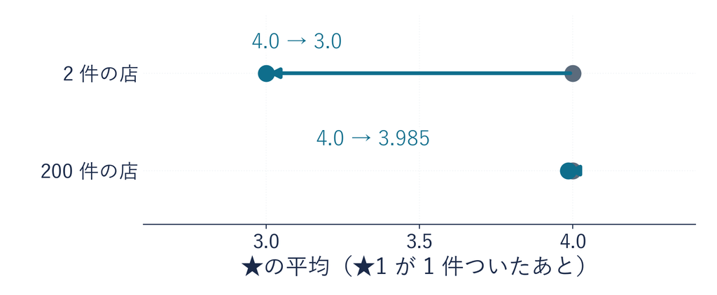

**2 件の店**：4.0 ＋（1 − 4.0）÷ 3 ＝ 3.0

**200 件の店**：4.0 ＋（1 − 4.0）÷ 201 ≈ 3.985

星を見るときは、件数も見る。件数の少ない店の星は 1 件で大きく動く

## 古い平均・ずれ・新しい平均

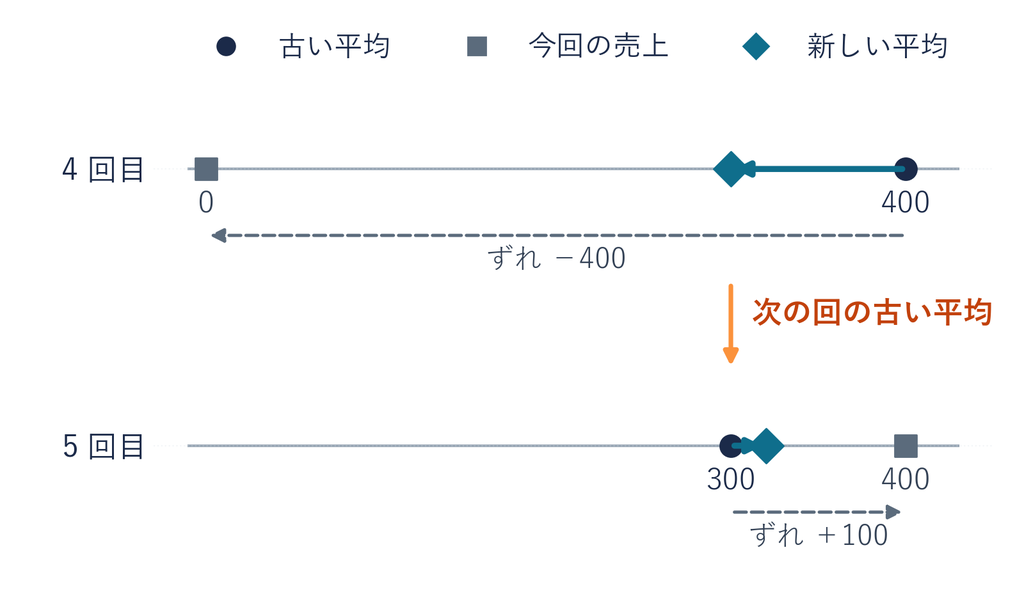

**4 回目**：ずれ −400 の 4 分の 1 だけ下がり、400 → 300

**5 回目**：古い平均 300 から、ずれ ＋100 の 5 分の 1 だけ上がり、320

新しい平均が、次の回の古い平均になる

## 更新の式で直す最初の 5 回

p.8 の記録

400 円を見せた最初の 5 回：400・400・400・0・400

1 回目

$0 + (400 - 0) \div 1$

$= 400$

÷1 なので、今回の売上そのもの

2・3 回目

$400 + (400 - 400) \div 2$

$= 400$

ずれは 0 で、3 回目も動かない

4 回目

$400 + (0 - 400) \div 4$

$= 300$

ずれ −400 の 4 分の 1

5 回目

$300 + (400 - 300) \div 5$

$= 320$

ずれ ＋100 の 5 分の 1

合計 ÷ 回数と同じ 400・400・400・300・320 に着く

別の問い

入口の問い（p.7）  
1 回売れなかった 400 円

1 回目 売れず 0 →  
2 回目 売れた 400

$0 + (400 - 0) \div 2$  
$= 200$

答えは ②  
見せた回数は 2

## 見せた回数と 1 回で動く幅

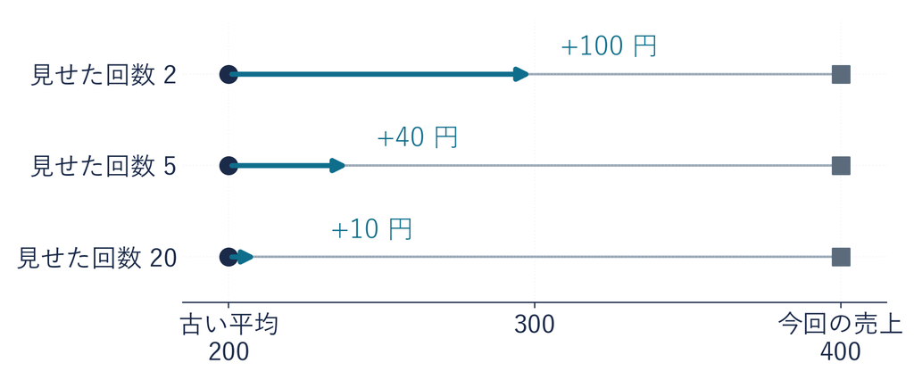

なぜ ÷ 見せた回数か：古い合計 ＝（見せた回数 − 1）× 古い平均  
今回の売上を足し、見せた回数で割ると、更新の式と同じ数

見せた回数が少ない値段ほど、1 回で大きく動く

## 400 円の 10 回の平均の経路

今度は前の回の 20 人の記録で、400 円の 10 回を同じ式で 1 回ずつ直す

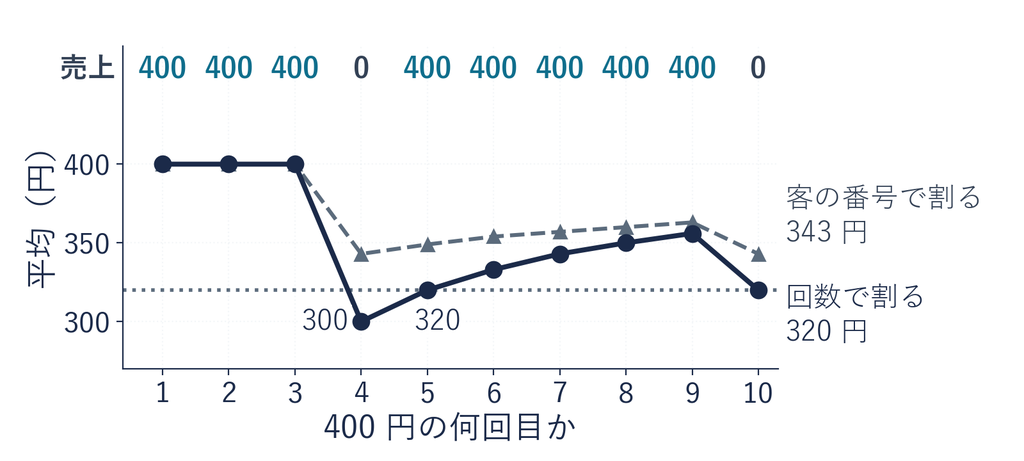

最後は前の回の 3200 ÷ 10 ＝ 320 と同じ所に着く

前の回：10 回の売上を全部並べて、合計 ÷ 回数で出し直した  
今日：帳簿にある平均と見せた回数の 2 つから直接直す（合計を持つ手もある）

## 更新の関数の写経

```python
def update(q, n, r):        # 平均を 1 回ぶん直す
    return q + (r - q) / n  # 古い平均 ＋ ずれ ÷ n
print(update(0, 2, 400))    # 入口の問い
```

| 行 | 部品 | 中身 |
| --- | --- | --- |
| 1 | **① 名前と材料** | 名前は update。材料は 3 つ q 古い平均・n 見せた回数・r 今回の売上 |
| 2 | **② 返す値** | p.9 の更新の式 古い平均 ＋ ずれ ÷ 見せた回数 |
| 3 | **③ 確かめ** | 入口の問いを入れて表示 平均 0 円・2 回目・売上 400 円 |

※ 400 円の 10 回を 1 回ずつ直すループは、ノートの実行セルに用意してある（写さずに実行）

## 更新の関数の写経と実行

1. **＋ コード**で  
   セルを足す
2. p.15 の 3 行を  
   上から写す
3. **▶** か **Shift + Enter** で実行  
   （Mac は Shift + return）
4. 下の実行セルも実行し  
   5 回目と 10 回目の  
   320 を探す

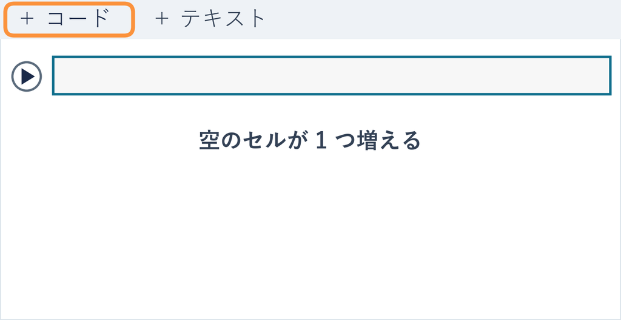

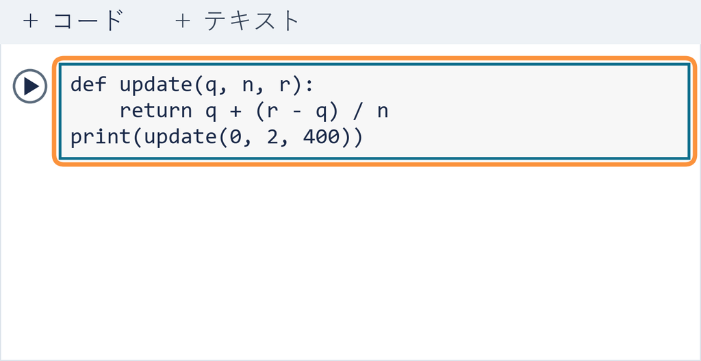

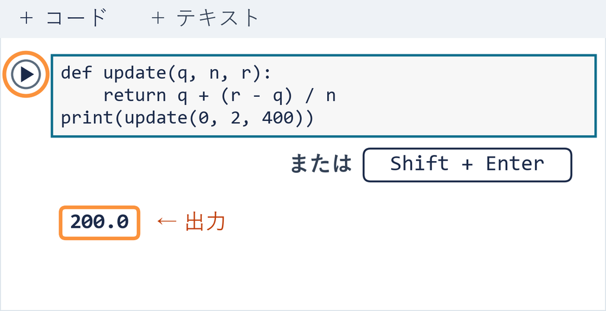

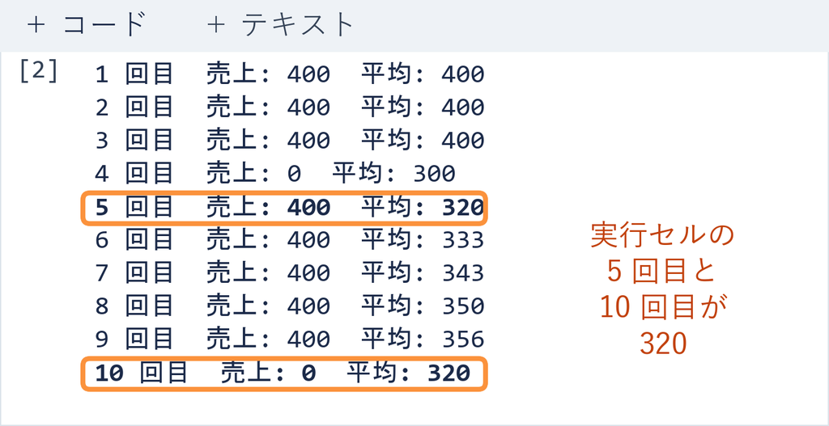

⏸ PAUSE 動画を止めて $3$ 分。200.0 と 10 行が出たら再生に戻る

出力の 200.0 は入口の問いの答え（②）。実行セルの 5 回目と 10 回目は 320

## 演習1 800 円の 10 回

演習 1

800 円の 10 回を、1 回ずつ直す

```python
sales = [400, 400, 400, 0, 400, 400, 400, 400, 400, 0]   # ← ここを書き換える
q = 0                              # 1 回目は ÷1 なので、始めは 0 でよい
for n, r in enumerate(sales, 1):   # n に 1, 2, 3 …、r に売上
    q = update(q, n, r)
    print(n, "回目  売上:", r, " 平均:", round(q))
```

1. **書き換える**：実行セルをコピーして、**＋ コード**で足したセルに貼り  
   1 行目を 800 円の 10 回 `[800, 800, 0, 800, 800, 0, 800, 0, 0, 800]` に
2. **予想する**：3 回目は売れない。そのときの平均はいくつか
3. **終わり**：実行して、10 行が出たら

⏸ PAUSE 動画を止めて $3$ 分。10 行が出たら再生に戻る

## 演習1の答え

| 回目 | 1 | 2 | 3 | 4 | 5 | 6 | 7 | 8 | 9 | 10 |
| --- | --- | --- | --- | --- | --- | --- | --- | --- | --- | --- |
| 売上 | 800 | 800 | 0 | 800 | 800 | 0 | 800 | 0 | 0 | 800 |
| 平均 | 800 | 800 | 533 | 600 | 640 | 533 | 571 | 500 | 444 | 480 |

- **答え**：3 回目は約 533 円。ずれ −800 の 3 分の 1、約 267 円下がる
- **10 回目**：480 円。1 回ずつ直した平均は、  
  いつも合計 ÷ 回数と同じ（4800 ÷ 10）

どちらの値段でも、1 回ずつ直した平均は合計 ÷ 回数と同じ所に着く

※ manaba に置いた別ファイルのデモ（lecture10_learn_demo.html）で、1 回ずつ直す帳簿を自分でも動かせる

## まとめ

疑問 1 回売れなかった 400 円が  
2 回目に売れたら、平均はどう直すか

回答 ずれの n 分の 1 だけ直す  
直した平均が、次の古い平均になる

更新は平均を直す道具で、値段の選び方は変えていない  
見せない値段の平均は、直らない

経済プログラミング特論II

第10回・開店 12 日目 — Topic02

ε-greedy 法

見せなかった値段も、たまに確かめ直す

## 400 円を二度と見せなかった客の並び

**これまで**：平均は 1 回ずつ直せる。でも値段の選び方は変えていない

**場面**：学生の店の記録。1 人目の客に見せた 400 円は売れず、2 人目の 800 円は売れた  
そのあと店長は、400 円を 100 人目まで一度も客に見せなかった（seed 15）

**引っかかり**：400 円は 1 回売れなかっただけ。選ばなかった値段を確かめ直す仕組みが無い

5 人に 1 人くらいの客に、2 つの値段のどちらかを  
わざと見せて試す店長なら、400 円をもう一度客に見せるか

- **①** もう一度見せる
- **②** 見せない

動画を止めて、①・②から1つ選んで、少し考えてから再生

## ε-greedy 法

**ふだんは一番、たまにわざと**

定義

**ε-greedy 法**確率 ε で、400 円か 800 円を半々で試す  
それ以外は、平均が高いほう（同じなら 400 円）

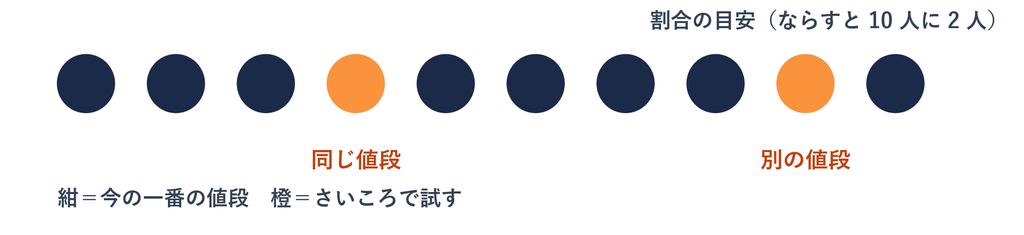

- **割合**：試すのは 5 人に 1 人（ε ＝ 0.2・コードでは eps）。別の値段になるのは 10 人に 1 人
- **名前の由来**：greedy は「欲ばり」（いま平均が一番の値段）、ε は寄り道する小さな割合

## 1 人の客の手順：4 つの STEP

**方策（値段を選ぶ決まり）**：前の店長はいつも平均の高いほう ／ 今日は ε-greedy 法

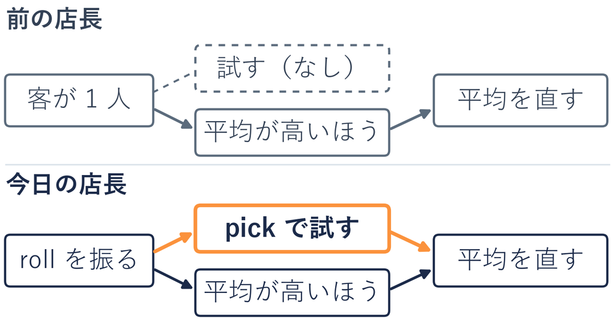

手順

STEP 1**店長のさいころ roll を振る**：0 から 1 までの数が、どれも同じ起きやすさで出る

STEP 2**roll が 0.2 未満なら試す**：さいころ pick で値段（0.5 以上なら 800 円）

STEP 3**そうでなければ平均が高いほう**（同じなら 400 円）

STEP 4**平均を直す**：売れたかを見て、見せた値段の平均だけ

最初の 2 人は 400 円と 800 円を 1 回ずつ（どちらの平均も 0 円のままでは比べられないので）・店長のさいころは客とは別に振る

## seed 15 の 6〜10 人目

前の回と同じ seed 15 の客の並び。1〜5 人目は前の回の店長と同じ値段を見せた

| 客 | roll | pick | 試すか | 値段 | 売れたか | 400 円の回数 | 400 円の平均 | 800 円の回数 | 800 円の平均 |
| --- | --- | --- | --- | --- | --- | --- | --- | --- | --- |
| 1〜5 | — | — | — | — | — | 1 | 0 | 4 | 400 |
| 6 | 0.13 | 0.41 | 試す | 400 | ○ | 2 | 200 | 4 | 400 |
| 7 | 0.00 | 0.85 | 試す | 800 | × | 2 | 200 | 5 | 320 |
| 8 | 0.14 | 0.05 | 試す | 400 | ○ | 3 | 267 | 5 | 320 |
| 9 | 0.07 | 0.77 | 試す | 800 | × | 3 | 267 | 6 | 267 |
| 10 | 0.89 | — | 平均で | 400 | × | 4 | 200 | 6 | 267 |

6 人目の試しで 400 円が売れ、400 円の平均が 0 から 200 に直った

試す値段は半々なので、売れにくい 800 円とは限らない（売れやすい 400 円のこともある）

前の店長なら：6〜10 人目もずっと 800 円。400 円は 1 回きりで、平均 0 円のまま

## 同じ客の 100 人で 2 人の店長

同じ seed 15 の客の並びで、2 人の店長を並べる（客もさいころも同じ）

**1 本**：客の並びを 1 つ決めて、100 人ぶん営業させた記録（前の回と同じ数え方）

**条件**：800 円から始めた（1 人目の 400 円は売れず、2 人目の 800 円が売れた）／買う割合は 400 円 8 割・800 円 3 割

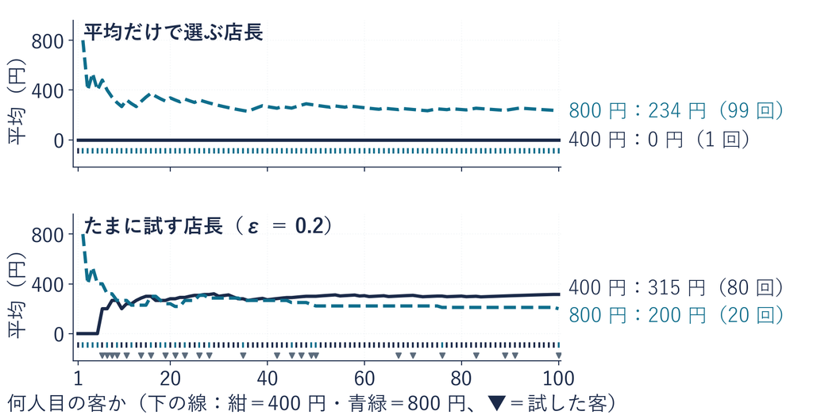

400 円は平均だけ 1 回・たまに試す 80 回（平均 315 円）

## 100 人ぶんの帳簿

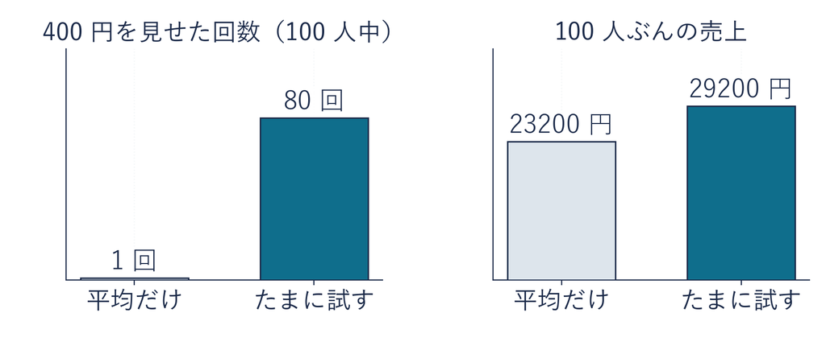

**平均だけで選ぶ店長**：400 円 1 回・0 円／800 円 99 回・234 円

**たまに試す店長**：400 円 80 回・315 円／800 円 20 回・200 円

売上は 23200 円 → 29200 円。この客の並びでは 6000 円多い

## デモ 帳簿：たまに試す店長

この枚のねらい

5人に1人くらい半々で試し、あとは平均が高いほう

- **何を見るか**：400 円を出した回数（2 人の店長で比べる）
- **図の意味**：上＝帳簿と更新の1行／下＝平均の線・▼＝試した客
- **操作**：タブで店長を選ぶ・▶ で客を1人・▶▶ で10人  
  （ほかのタブは、あとで使う）

ミッション ▶▶ 最後まですすめる を押し、  
タブで 400 円の回数を比べる

※ 次のスライドへ進むときは、デモの枠の外を一度クリックしてから ← → キーを押す

[interactive chart not shown]

## choose 関数の写経

```python
def choose(q, eps, coin):                      # 次の客に見せる値段を選ぶ
    roll, pick = coin.random(), coin.random()  # 店長のさいころを 2 回
    if roll < eps:                             # 確率 eps で試す
        return 800 if pick >= 0.5 else 400     # 400 円か 800 円を半々で
    return higher(q)                           # ふだんは平均が高いほう
```

| 行 | 部品 | 中身 |
| --- | --- | --- |
| 1 | **① 名前と材料** | 名前は choose。材料は 3 つ q 値段ごとの平均・eps 試す確率・coin 店長のさいころ |
| 2 | **② 2 つを同時に受け取る** | 左の roll と pick に、右の 2 つの数を順に入れる |
| 3-4 | **③ 試す（A if 条件 else B）** | 条件が当てはまれば A、そうでなければ B pick が 0.5 以上なら 800、未満なら 400 |
| 5 | **④ ふだん** | higher(q)：平均が高いほう（同じなら 400 円） |

前の回の店長から増えたのは 2〜4 行目、結果を変えるのは 3・4 行目

**STEP 1** **＋ コード**でセルを足し、5 行を写して実行（何も出ない） **STEP 2** 下の実行セルも実行し、80 と 29200 を探す

⏸ PAUSE 止めて Colab で写して実行（目安 5 分）。80 と 29200 が出たら再生に戻る

## 演習2 eps を 0 にした店長

演習 2

さいころの割合を 0 にすると、売上はどうなるか

```python
q, count, sales = eps_greedy(15, 0.2)   # ← ここを書き換える
for a in [0, 1]:
    print("値段", PRICES[a], " 見せた:", count[a], "回  平均:", round(q[a]))
print("100 人ぶんの売上:", sales)
```

1. **書き換える**：実行セルをコピーして  
   **＋ コード**で足したセルに貼り、1 行目の 0.2 を 0 に
2. **予想する**：売上は ① 29200 円のまま ② 前の回の 23200 円に戻る ③ その間
3. **終わり**：実行して、3 行が出たら

⏸ PAUSE 動画を止めて $3$ 分。3 行が出たら再生に戻る

## 演習2の答え

| eps | 400 円の回数 | 400 円の平均 | 800 円の回数 | 800 円の平均 | 売上 |
| --- | --- | --- | --- | --- | --- |
| 0.2（帳簿のページ） | 80 | 315 | 20 | 200 | 29200 |
| 0 | 1 | 0 | 99 | 234 | 23200 |

- **答え**：② 23200 円に戻る。400 円は 1 回きり
- **理由**：eps が 0 だと roll ＜ 0 は起きず、試す 2 行（3・4 行目）が働かない

ε が 0 なら、前の回の店長と同じ。違いは試す 2 行だけ

## まとめ

疑問 たまにわざと試す店長なら、  
400 円をもう一度客に見せるか

回答 見せる。ふだんは一番、たまにわざと試すので  
平均の低い値段にも、もう一度出会える

経済プログラミング特論II

第10回・開店 12 日目 — Topic03

学習の評価

平均では少し損、出だしの不運には強い

## 1 本の記録の限界

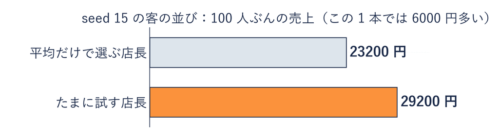

客の並びを 200 通りに替えると、  
売上が多い記録が多いのは、どちらの店長か

**①** たまに試す店長 **②** 平均だけで選ぶ店長 **③** だいたい半々

動画を止めて、①〜③から1つ選んで、少し考えてから再生

## 比べ方：同じ客・同じさいころ

統制した比較（前に出てきた）：比べたいもの以外を、全部そろえる

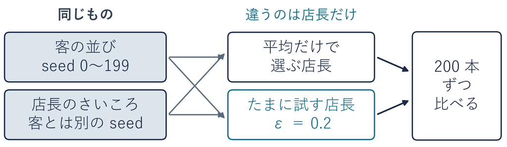

平均だけで選ぶ店長は、値段をさいころで決めない。  
でも毎回振って、目は捨てる  
だから何人目の客にも、  
2 人の店長で同じ目が出る。違うのは店長だけ

店長は知らない店の設定で、よい値段は 400 円  
ならすと 1 人あたり 400 × 0.8 ＝ 320 円 ／ 800 × 0.3 ＝ 240 円

## 4 本での 2 人の比較

200 本から 4 本を選んだ例（ふつうの出だし 3 本・出だしが悪い 1 本）

**営業中の売上**学びながら得た、100 人ぶんの売上の合計

**学習後の選択**100 人の後、平均が高いほうの値段

| seed | 出だし | 売上・平均だけ | 売上・たまに試す | 最後・平均だけ | 最後・たまに試す |
| --- | --- | --- | --- | --- | --- |
| 0 | ふつう | 27600 | 25200 | 400 | 400 |
| 1 | ふつう | 32000 | 30400 | 400 | 400 |
| 3 | ふつう | 28000 | 24400 | 400 | 400 |
| 15 | 悪い | 23200 | 29200 | 800 | 400 |

売上は平均だけが 3 本で上。最後の値段は、  
たまに試す店長が 4 本とも 400 円

## 最後に選ぶ値段：200 本

今度は 200 本で、同じ 2 つの物差しを数える。まず学習後の選択

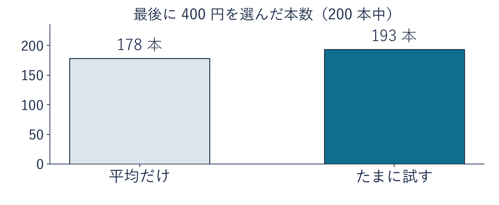

最後に 400 円：平均だけ 178 本 ／ たまに試す 193 本

## 100 人ぶんの売上の差：200 本

差＝たまに試す − 平均だけ。読み方：seed 0 は 25200 − 27600 ＝ −2400 円 → 0 の左  
記録 1 本＝客 100 人の営業。棒の高さ＝その差になった記録の本数

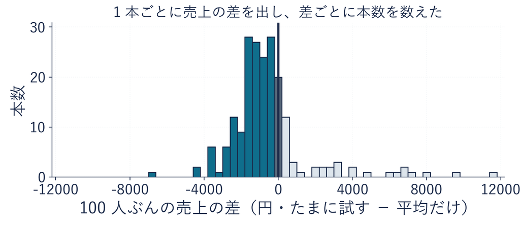

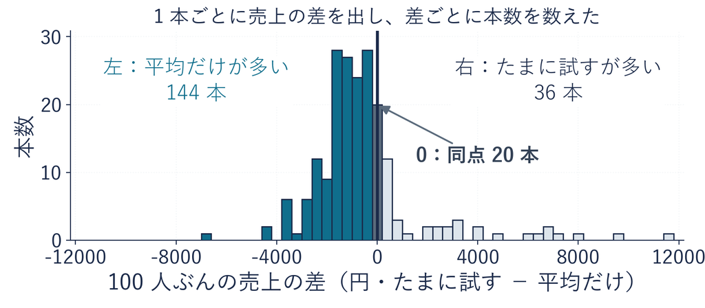

0 の左（平均だけが多い）が 144 本。入口の答えは ②

seed 15 の 1 本だけなら：見えるのは右の＋6000 円の棒に入る 1 本だけ

## 試しの費用：ふつうの出だし 185 本

試した客の半分には 800 円を見せる  
800 円は 400 円より、1 人あたりの期待値が 80 円低い（320 − 240 ＝ 80）

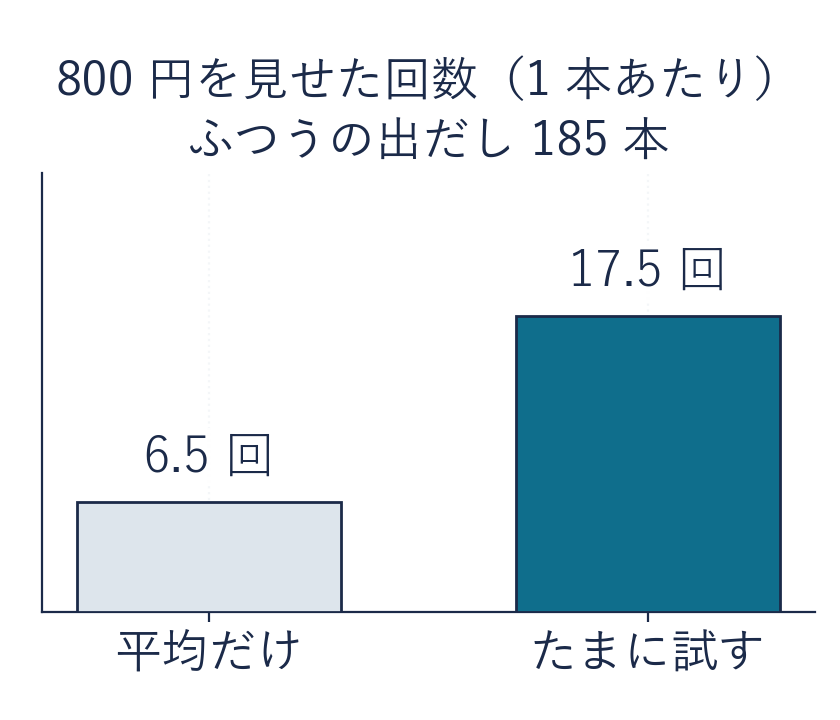

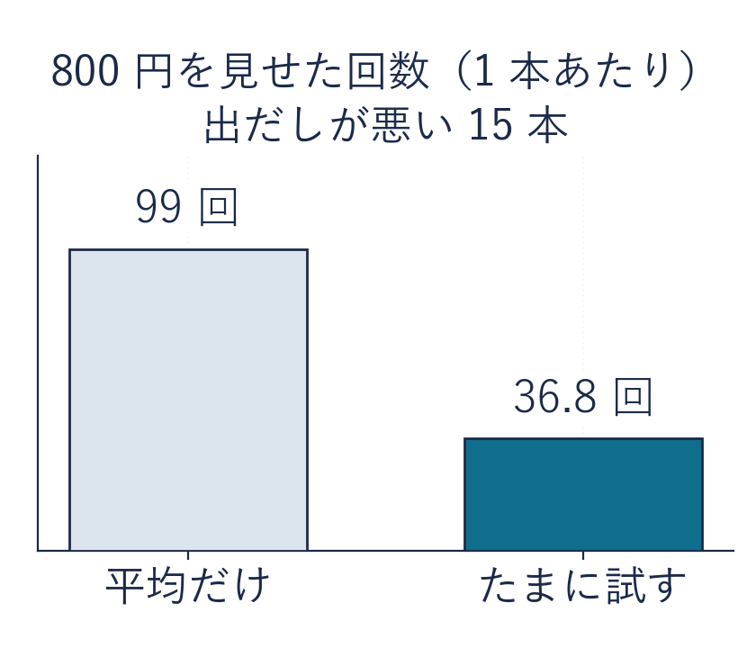

多く見せた回数

$17.5 - 6.5$

$= 11$

800 円を約 11 回多く見せる

ならした損

$11 \times 80$

$= 880$

約 880 円の損（実測 945 円）

100 人で 945 円＝1 人あたり約 9 円の損

## 試しの効き目：出だしが悪い 15 本

1 人目の 400 円が売れず、2 人目の 800 円が売れた記録（200 本中 15 本だけ）

少なく見せた回数

$99 - 37$

$= 62$

試す店長は約 37 回だけ

取り戻す額

$62 \times 80$

$= 4960$

約 5000 円取り戻す（実測 4720 円）

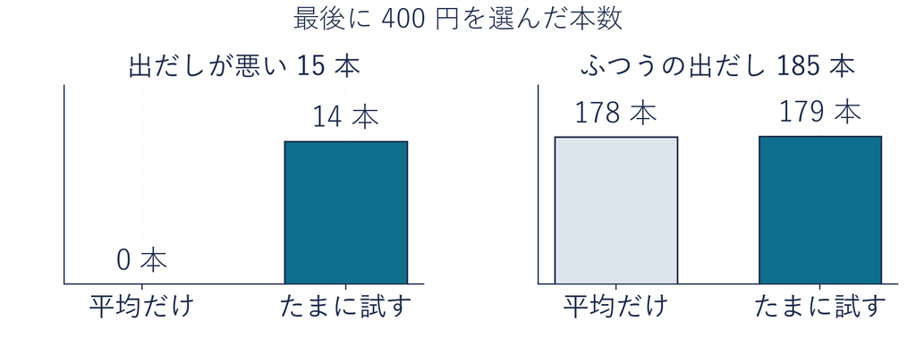

いちばん少ない売上（どちらも seed 22）：平均だけ 16000 円 → たまに試す 20800 円

## 試しの損得：200 本の答え

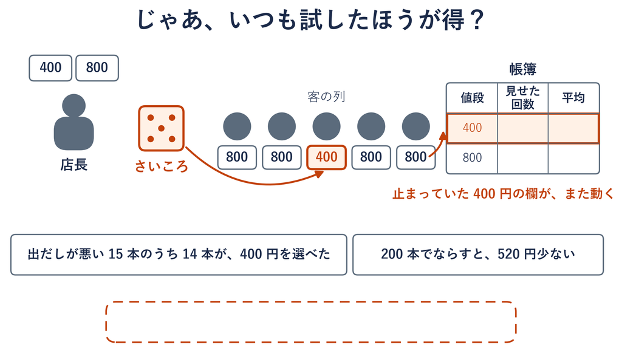

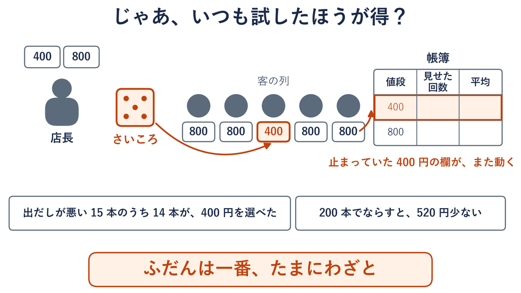

## デモ 帳簿：200本の比較

この枚のねらい

同じ客・同じさいころで、店長だけ替えて200本

- **何を見るか**：売上の平均  
  （全体と、出だしが悪い本で切り替えて比べる）
- **図の意味**：上の1行＝売上の平均／棒の1組目＝最後に 400 円を選んだ  
  本数・2組目＝売上が多かった本数
- **操作**：比べる本を選ぶ・▶ で20本ずつ・▶▶ で全部

ミッション 出だしが悪い記録だけに切り替えると、  
売上はどちらが上か。予想してから押す

※ 次のスライドへ進むときは、デモの枠の外を一度クリックしてから ← → キーを押す

[interactive chart not shown]

## 200 本で 2 人の店長を比べる写経

```python
more = 0                                      # 平均だけの売上が多かった本数
for s in range(200):                          # 客の並び 200 通り
    q, count, avg_sales = eps_greedy(s, 0)    # 平均だけで選ぶ店長
    q, count, try_sales = eps_greedy(s, 0.2)  # たまに試す店長（同じ客）
    more += avg_sales > try_sales             # 平均だけが多ければ 1 を足す
```

| 行 | 部品 | 中身 |
| --- | --- | --- |
| 1 | **① 数える箱** | more を 0 から始める（平均だけの売上が多かった本数） |
| 2 | **② 200 通りの客** | s に 0〜199 を 1 つずつ入れて、下の 3 行をくり返す |
| 3-4 | **③ 同じ客で 2 人** | eps 0 は平均だけ、0.2 はたまに試す 3 つ目の売上を avg_sales と try_sales で受ける |
| 5 | **④ 当てはまれば 1** | 平均だけが多ければ 1、そうでなければ 0 を足す （前の回の形・同点は数えない） |

数えるだけのセルなので、実行しても何も出ない（3 つの数を出す compare はノートの実行セル）

**STEP 1** 5 行を写して実行（何も出ない） **STEP 2** 下の実行セルで 144 と 178・193 を探す

## 演習3 eps を 0.1 にした店長

演習 3

試す客を半分にすると、売上の平均はどうなるか

```python
compare(0.2)   # ← ここを書き換える
```

1. **書き換える**：実行セルの compare(0.2) の行をコピーして  
   **＋ コード**で足したセルに貼り、0.2 を 0.1 に
2. **予想する**：売上の平均は、平均だけの 30886 円に（近づく／離れる）
3. **終わり**：実行して、3 行が出たら

⏸ PAUSE 動画を止めて $3$ 分。3 行が出たら再生に戻る

## 演習3の答え

| eps | 最後に 400 円 | 売上の平均 | 売上が多い記録の数 |
| --- | --- | --- | --- |
| 0（平均だけ） | 178 | 30886 | — |
| 0.2（写経の出力） | 193 | 30366 | 144 対 36 |
| 0.1 | 194 | 30700 | 132 対 37 |

- **答え**：近づく。試す客が減ると、試しの費用も減る
- **ただし**：出だしが悪い 15 本で、最後に 400 円を選べたのは 12 本（0.2 なら 14 本）

試す割合を減らすと、損は減るが、直せる記録も減る

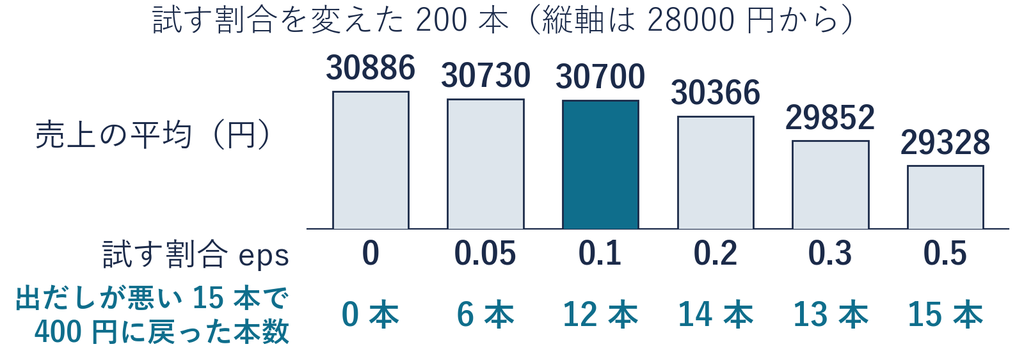

同じ買う割合で客が 300 人なら、いちばん売上が高いのは eps 0.1

## まとめ

疑問 いつも試したほうが得か

回答 いつもではない。試すと誤解を直す機会は得る  
この店では、平均では費用のほうが大きかった  
どの並びが来るかは、先に分からない

比べ方：客とさいころをそろえ、店長だけ替えた  
売上と最後の値段は、別々に数えた

経済プログラミング特論II

第10回・開店 12 日目 — Topic04

店の状態と移り変わり

残りの人数と在庫の組で、店のいまを書く

## 品が 1 点しかない店

**これまで**：品は作り足せたので、平均の高い値段を見せればよかった

**困りごと**：手作りの 1 点ものは、品が 1 点しかない。売れた 1 個は、次の客には売れない

**仮定**：受付の締め切りまでに、あと何人がページを開くか（残りの人数）は分かっている

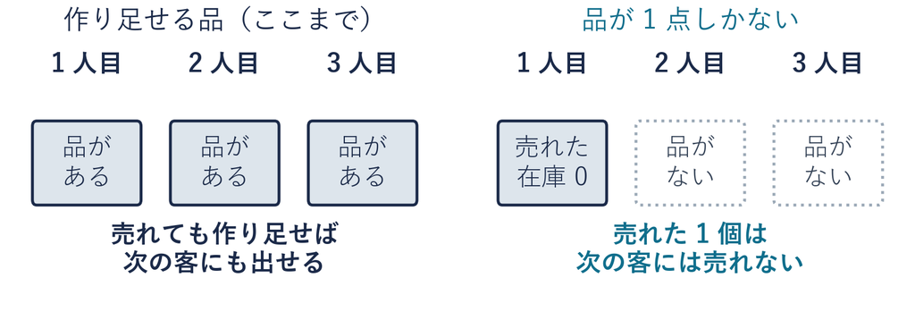

在庫 1 個で、残り 1 人と残り 30 人では、値段の選び方は同じか  
**①** 同じ（在庫はどちらも 1 個） **②** 同じとは限らない

動画を止めて、①か②を選んで、少し考えてから再生

## 状態：残りの人数と在庫の組

いまの状態（残りの人数, 在庫）

(2, 1)

決める言葉は 2 つ：**状態**と**残りの人数**

**いまの店の様子を、2 つの数で言い表したもの**

**状態**(残りの人数, 在庫) の組  
(2, 1) なら残り 2 人・在庫 1 個

**残りの人数**受付の締め切りまでに  
あと何人がページを開くか

- **売れたら**：在庫が 1 つ減り、残りの人数も 1 つ減る
- **売れなくても**：残りの人数は 1 つ減る
- **受付終了**：在庫 0 か、残りの人数が 0 になったら

入口の答えは ②。在庫が同じでも、残りの人数が違えば別の状態

## 残り 2 人・在庫 1 からの分かれ道

いまの状態（残りの人数, 在庫）

(2, 1)

状態 (2, 1) の店に、1 人目がページを開く

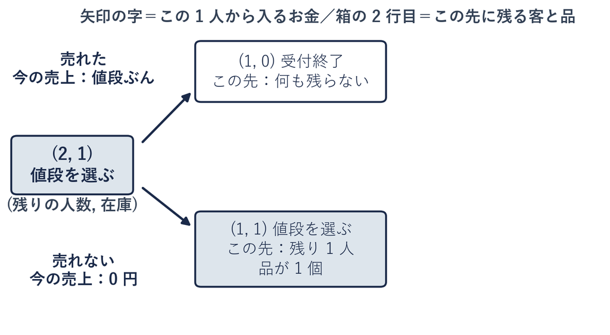

作り足せる店なら：売れても品を足すので、次の客の前もいつも同じ店  
1 点ものは：売れたら (1, 0) で受付終了

1 人目が買うかどうかで、次の状態が (1, 0) と (1, 1) に分かれる

## 2 人目までの分かれ道

いまの状態（残りの人数, 在庫）

(1, 1)

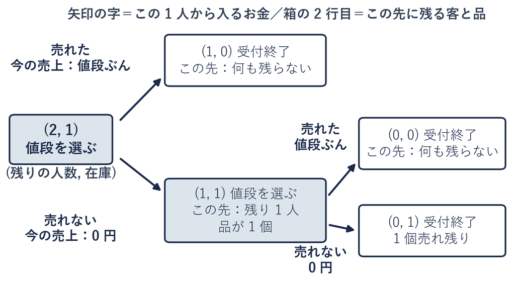

- **値段が動かすもの 1**：今の売上（売れたら値段ぶん、売れなければ 0 円）
- **値段が動かすもの 2**：どちらの箱へ進みやすいか  
  （400 円なら 10 人に 8 人、800 円なら 10 人に 3 人が買う）

## 状態の 6 マス

状態の書き方

(残りの人数, 在庫)

残り 1〜3 人 × 在庫 1〜2 の表（左＝開店の残り 3 人・右＝締め切りの残り 1 人）

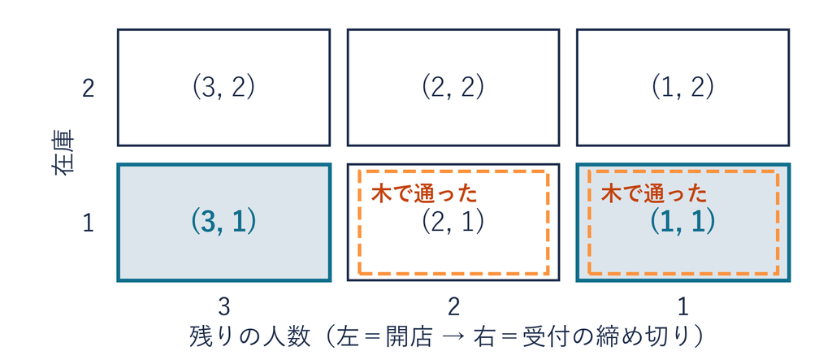

同じ在庫 1 でも、残り 1 人の (1, 1) と、残り 3 人の (3, 1) は別の状態

考える：(3, 2) で 1 人がページを開いたら、次の状態は？  
売れた → (2, 1) ／ 売れない → (2, 2)（どちらも 1 つ右の列）